# Bayesian Structural Equation Modeling

09-03-2022

## Overview

- Introduction
  - Bayesian analysis
  - Why use Bayesian SEM?
  - Why not to use Bayesian SEM?
- Prior specification
  - Hands-on session prior specification
- A Bayesian SEM example
- Exercises
- Additional information

## Introduction

## Bayesian analysis

**Frequentist estimation**

- Probability as long-run relative frequency
- Parameters are fixed
- Estimation through optimization

**Bayesian estimation**

- Probability as belief
- Parameters are random and can be assigned a *prior*
- Estimation through sampling

## Bayesian analysis

Bayesian estimation relies on the data and the prior: \[ p(\pmb{\theta}|Y) \propto p(Y|\pmb{\theta})p(\pmb{\theta}) \]

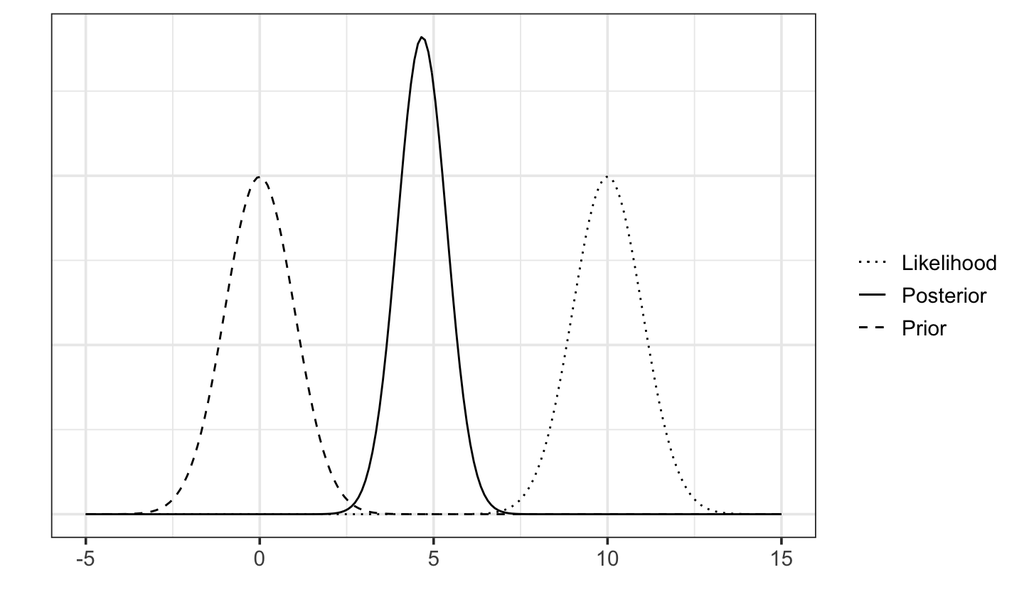

## Why use Bayesian SEM?

Bayesian SEM: specify a prior for each parameter and build the posterior using MCMC sampling.

*Advantages*

- Add information via the prior
  - smaller samples needed
  - regularization of estimates
- More complex models can be estimated
- Automatic uncertainty estimates

## Why not to use Bayesian SEM?

- Add information via the prior
- MCMC sampling requires assessment of convergence
- Relatively novel
  - active area of research
  - availability in software
  - researchers unfamiliar

## Questions?

## Prior specification

## Types of priors

- Priors vary in the amount of information they carry
- From “non-informative” to highly informative
- Informativeness of the prior depends on the problem

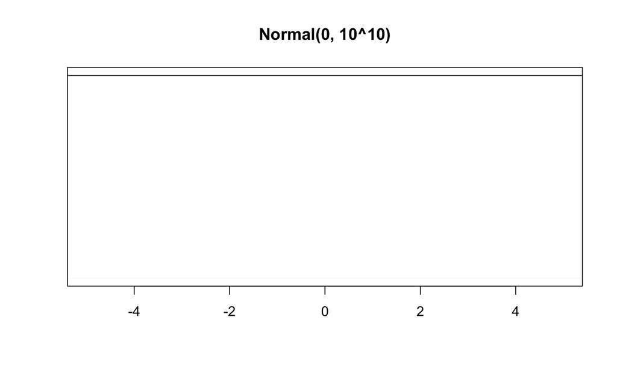

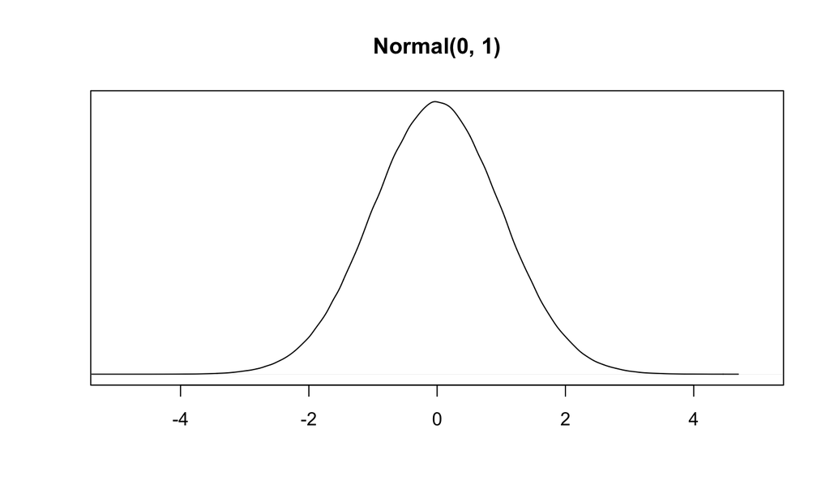

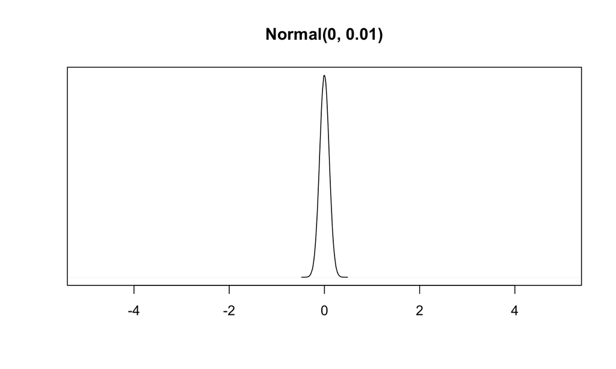

## A warning on default priors

- Traditionally, heavy reliance on “default” priors
- Adding no information through the prior can give the same results as ML
- But: default priors can inadvertently influence the results, e.g. IG(.001, .001) prior (e.g., van Erp et al. (2018); van Erp & Browne (2021))
- Some software programs are not explicit about their priors, but it can be influential

## The power of the prior

- Weakly informative priors to regularize estimates
- Informative priors to include prior research or expert opinions
- Shrinkage priors to identify non-identified models

## How to be careful with the prior

- Carefully consider the priors (or look up the automatic defaults)
- Visualize your priors
- Conduct a prior sensitivity analysis

## Hands-on: Prior specification with Shiny BSEM

Go to: https://github.com/sara-vanerp/shinyBSEM

Think about reasonable priors for all parameters (or use the defaults) and inspect the results.

Change the priors to see how this influences the results.

## A Bayesian SEM example with blavaan

## Political democracy example

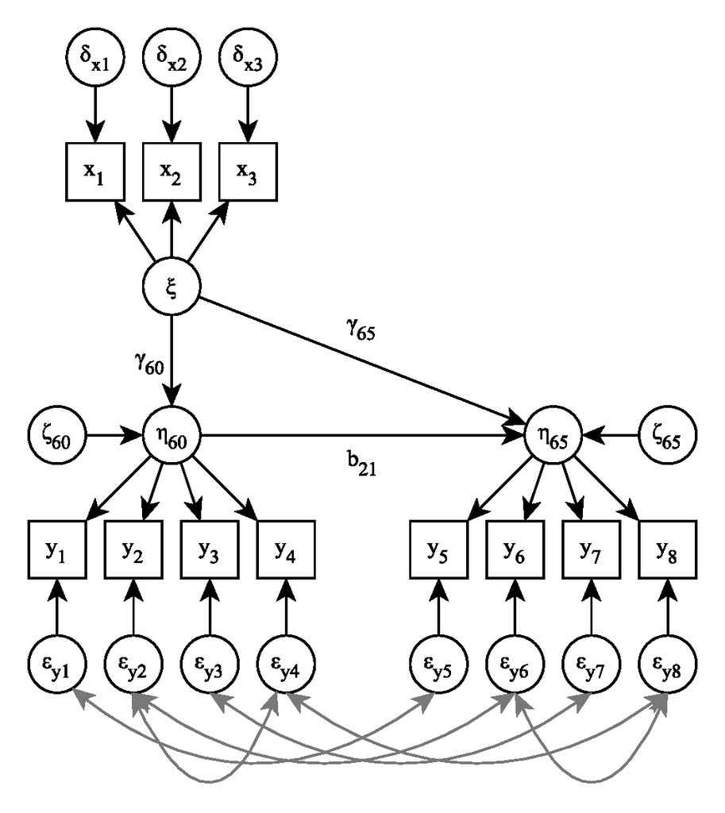

## Packages

```r
library(blavaan)
library(bayesplot)
```

## Step 1: Define the model

See the [lavaan website](https://lavaan.ugent.be/tutorial/index.html) for more information about lavaan syntax.

```r
mod0 <- '
  # measurement model
    ind60 =~ x1 + x2 + x3
    dem60 =~ y1 + y2 + y3 + y4
    dem65 =~ y5 + y6 + y7 + y8
  # regressions
    dem60 ~ ind60
    dem65 ~ ind60 + dem60
  # residual correlations
    y1 ~~ y5
    y2 ~~ y4 + y6
    y3 ~~ y7
    y4 ~~ y8
    y6 ~~ y8
'
```

## Step 2: Priors - blavaan defaults

```r
# check the blavaan defaults
dpriors()
```

```
##                nu             alpha            lambda              beta
##    "normal(0,32)"    "normal(0,10)"    "normal(0,10)"    "normal(0,10)"
##             theta               psi               rho             ibpsi
## "gamma(1,.5)[sd]" "gamma(1,.5)[sd]"       "beta(1,1)" "wishart(3,iden)"
##               tau             delta
##   "normal(0,1.5)" "gamma(1,.5)[sd]"
```

## Step 2: Priors - plotting the defaults (1)

```r
priors0 <- bsem(mod0,
                data = PoliticalDemocracy,
                prisamp = TRUE,
                sample = 1000)
```

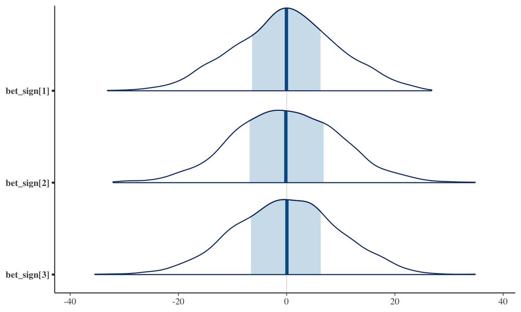

```r
samples0 <- as.matrix(blavInspect(priors0, what = "mcmc"))
pars <- dimnames(samples0)[[2]]
mcmc_areas(na.omit(samples0),
           pars = pars[9:11])
```

## Step 2: Priors - plotting the defaults (2)

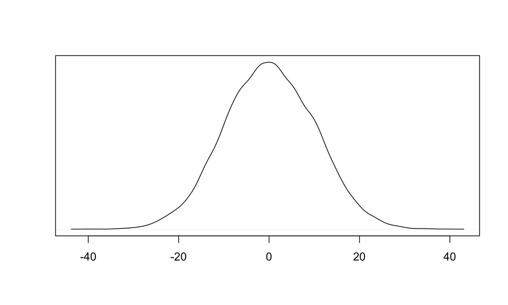

```r
plot(density(rnorm(10000, mean = 0, sd = 10)),
     xlab = "", ylab = "", main = "", yaxt = "n")
```

## Step 2: Change the priors (1)

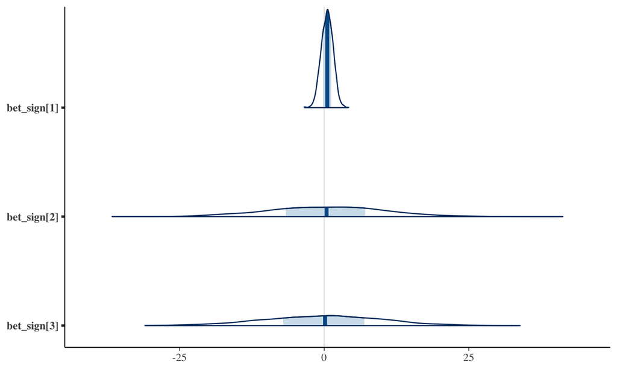

```r
mod1 <- '
  # measurement model
    ind60 =~ x1 + x2 + x3
    dem60 =~ y1 + y2 + y3 + y4
    dem65 =~ y5 + y6 + y7 + y8
  # regressions
    dem60 ~ prior("normal(0.5, 1)")*ind60
    dem65 ~ ind60 + dem60
  # residual correlations
    y1 ~~ y5
    y2 ~~ y4 + y6
    y3 ~~ y7
    y4 ~~ y8
    y6 ~~ y8
'
priors1 <- bsem(mod1,
                data = PoliticalDemocracy,
                prisamp = TRUE,
                sample = 1000)
samples1 <- as.matrix(blavInspect(priors1, what = "mcmc"))
mcmc_areas(na.omit(samples1),
           pars = pars[9:11])
```

## Step 2: Change the priors (2)

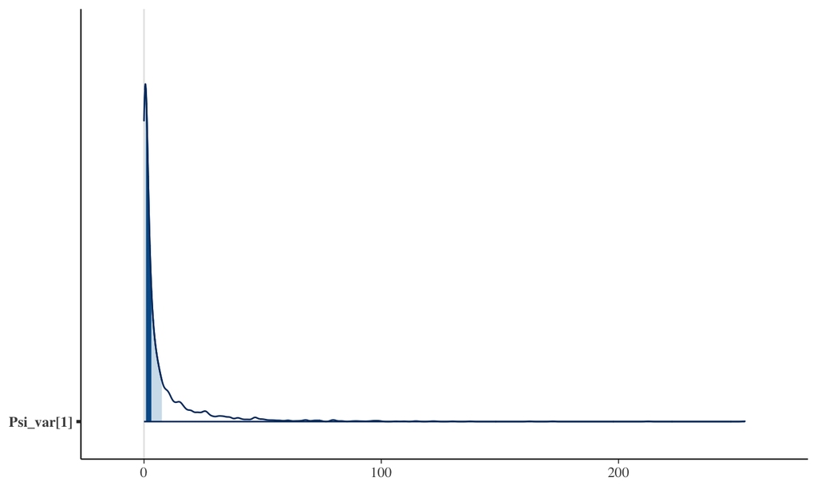

```r
mcmc_areas(na.omit(samples1),
           pars = pars[29])
```

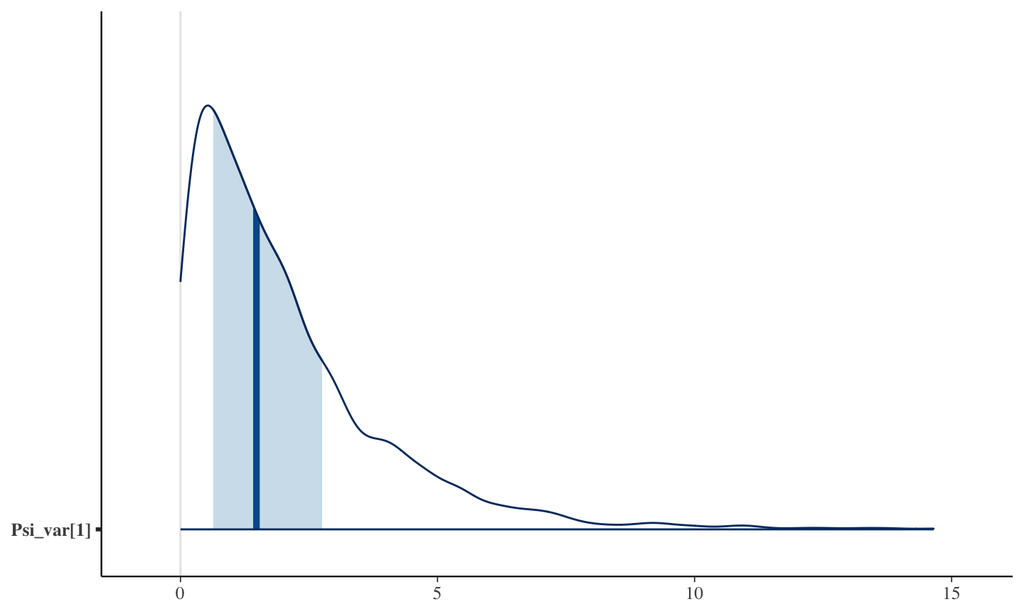

```r
priors2 <- bsem(mod0,
                data = PoliticalDemocracy,
                dp = dpriors(psi = "gamma(1,.5)[var]"),
                prisamp = TRUE,
                sample = 1000)
samples2 <- as.matrix(blavInspect(priors2, what = "mcmc"))
mcmc_areas(na.omit(samples2),
           pars = pars[29])
```

## Step 3: Run the model

```r
fit <- bsem(mod0,
            data = PoliticalDemocracy,
            n.chains = 3,
            burnin = 500,
            sample = 1000)
```

## Step 4: Check convergence

```r
summary(fit)
```

```
## blavaan (0.4-1) results of 1000 samples after 500 adapt/burnin iterations
##
##   Number of observations                            75
##
##   Number of missing patterns                         1
##
##   Statistic                                 MargLogLik         PPP
##   Value                                      -1682.411       0.496
##
## Latent Variables:
##                    Estimate  Post.SD pi.lower pi.upper     Rhat    Prior
##   ind60 =~
##     x1                1.000
##     x2                2.230    0.157    1.941    2.553    1.001    normal(0,10)
##     x3                1.843    0.164    1.529    2.169    1.000    normal(0,10)
##   dem60 =~
##     y1                1.000
##     y2                1.332    0.222    0.939    1.806    1.000    normal(0,10)
##     y3                1.104    0.170    0.800    1.464    1.000    normal(0,10)
##     y4                1.345    0.191    1.018    1.761    1.000    normal(0,10)
##   dem65 =~
##     y5                1.000
##     y6                1.234    0.192    0.900    1.639    1.000    normal(0,10)
##     y7                1.326    0.182    1.012    1.721    1.001    normal(0,10)
##     y8                1.325    0.189    1.000    1.722    1.000    normal(0,10)
##
## Regressions:
##                    Estimate  Post.SD pi.lower pi.upper     Rhat    Prior
##   dem60 ~
##     ind60             1.441    0.416    0.669    2.277    1.000    normal(0,10)
##   dem65 ~
##     ind60             0.543    0.244    0.088    1.037    1.000    normal(0,10)
##     dem60             0.851    0.111    0.651    1.095    1.001    normal(0,10)
##
## Covariances:
##                    Estimate  Post.SD pi.lower pi.upper     Rhat    Prior
##  .y1 ~~
##    .y5                0.747    0.412    0.023    1.649    1.001       beta(1,1)
##  .y2 ~~
##    .y4                1.241    0.731   -0.106    2.757    1.001       beta(1,1)
```

[output cut: 26 more lines]

```
##                    Estimate  Post.SD pi.lower pi.upper     Rhat    Prior
##    .x1                0.092    0.022    0.052    0.138    1.000 gamma(1,.5)[sd]
##    .x2                0.116    0.078    0.002    0.290    1.000 gamma(1,.5)[sd]
##    .x3                0.510    0.101    0.341    0.742    0.999 gamma(1,.5)[sd]
##    .y1                2.176    0.539    1.236    3.392    1.000 gamma(1,.5)[sd]
##    .y2                7.764    1.482    5.186   11.067    1.001 gamma(1,.5)[sd]
##    .y3                5.528    1.081    3.749    8.002    0.999 gamma(1,.5)[sd]
##    .y4                3.273    0.856    1.760    5.067    1.000 gamma(1,.5)[sd]
##    .y5                2.633    0.563    1.694    3.925    1.001 gamma(1,.5)[sd]
##    .y6                5.251    1.004    3.556    7.543    1.000 gamma(1,.5)[sd]
##    .y7                3.731    0.813    2.350    5.540    0.999 gamma(1,.5)[sd]
##    .y8                3.425    0.807    2.029    5.197    1.000 gamma(1,.5)[sd]
##     ind60             0.458    0.093    0.306    0.666    1.000 gamma(1,.5)[sd]
##    .dem60             3.851    1.029    2.164    6.148    1.000 gamma(1,.5)[sd]
##    .dem65             0.234    0.205    0.001    0.745    1.000 gamma(1,.5)[sd]
```

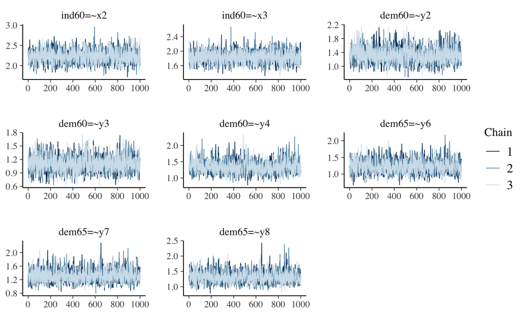

```r
plot(fit, pars = c(1:8), plot.type = "trace")
```

## Step 5: Check the results (1)

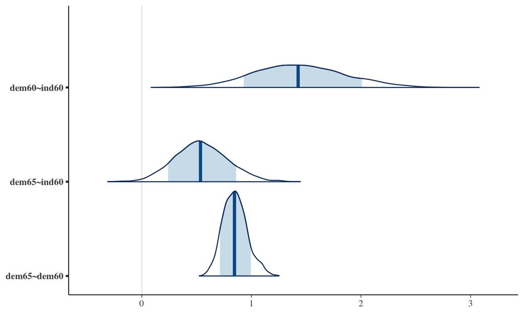

```r
plot(fit, pars = c(9:11), plot.type = "areas", prob = 0.8)
```

## Step 5: Check the results (2)

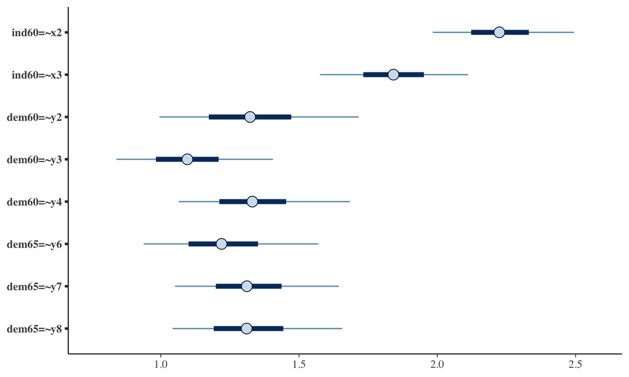

```r
plot(fit, pars = c(1:8), plot.type = "intervals", prob = 0.5, prob_outer = 0.9)
```

## Step 5: Check the results (3)

```r
fitind <- blavFitIndices(fit)
summary(fitind)
```

```
##
## Posterior summary statistics and highest posterior density (HPD) 90% credible intervals for devm-based fit indices:
##
##                EAP Median   MAP    SD lower upper
## BRMSEA       0.036  0.038 0.000 0.032 0.000 0.079
## BGammaHat    0.985  0.991 1.000 0.017 0.961 1.000
## adjBGammaHat 0.969  0.980 0.999 0.035 0.916 1.000
## BMc          0.960  0.974 0.999 0.045 0.893 1.000
```

## Step 5: Check the results (4)

```r
# define and fit the baseline model for computation of incremental fit indices
null.model <- c(paste0("x", 1:3, " ~~ x", 1:3), paste0("x", 1:3, " ~ 1"),
                paste0("y", 1:8, " ~~ y", 1:8), paste0("y", 1:8, " ~ 1"))
fit0 <- bsem(null.model, data = PoliticalDemocracy,
             n.chains = 3, burnin = 500, sample = 1000)
```

```r
fitind <- blavFitIndices(fit, baseline.model = fit0)
summary(fitind)
```

```
##
## Posterior summary statistics and highest posterior density (HPD) 90% credible intervals for devm-based fit indices:
##
##                EAP Median   MAP    SD lower upper
## BRMSEA       0.036  0.038 0.000 0.032 0.000 0.079
## BGammaHat    0.985  0.991 1.000 0.017 0.961 1.000
## adjBGammaHat 0.969  0.980 0.999 0.035 0.916 1.000
## BMc          0.960  0.974 0.999 0.045 0.893 1.000
## BCFI         0.991  0.994 1.000 0.011 0.975 1.000
## BTLI         0.989  0.991 0.990 0.023 0.953 1.027
## BNFI         0.945  0.946 0.945 0.013 0.924 0.965
```

## Step 6: Prior sensitivity analysis

- Rerun the analysis with different priors
- Change all priors for one type of parameter simultaneously
- When default priors are used, check different default priors
- When (weakly) informative priors are used, change the informativeness
- Report a range of results
- Focus on the outcome of interest (e.g. a specific estimate, whether a 95%CI contains 0, etc.)
- Goal is to get an idea of the robustness of the results

## Exercises

## Exercises

Work through the exercises [here](https://github.com/sara-vanerp/BSEMworkshop/blob/main/exercises.pdf). Feel free to adapt the exercises to work with your own data.

## Additional information

## References

*General Bayesian (introductory) texts*  
Etz, A., Gronau, Q. F., Dablander, F., Edelsbrunner, P. A., & Baribault, B. (2017). How to become a Bayesian in eight easy steps: An annotated reading list. Psychonomic Bulletin & Review, 25(1), 219–234.  
Depaoli, S., & Van de Schoot, R. (2017). Improving transparency and replication in Bayesian statistics: The WAMBS-Checklist. Psychological methods, 22(2), 240.  
Gelman, A., Carlin, J. B., Stern, H. S., Dunson, D. B., Vehtari, A., & Rubin, D. B. (2013). Bayesian data analysis (3rd ed.). Chapman and Hall/CRC.

*Bayesian SEM*  
Depaoli, S. (2021). Bayesian Structural Equation Modeling. Guilford Press.  
Lee, S-Y. (2007). Structural Equation Modeling: A Bayesian Approach. Wiley.

*Prior sensitivity*  
Van Erp, S., Mulder, J., & Oberski, D. L. (2018). Prior sensitivity analysis in default Bayesian structural equation modeling. Psychological Methods, 23(2), 363-388.  
Van Erp, S. & Browne, W. J. (2021). Bayesian Multilevel Structural Equation Modeling: An Investigation into Robust Prior Distributions for the Doubly Latent Categorical Model. Structural Equation Modeling: A Multidisciplinary Journal, 28:6, 875-893.

## References

*Blavaan*  
Merkle, E. C., & Rosseel, Y. (2018). blavaan: Bayesian Structural Equation Models via Parameter Expansion. Journal of Statistical Software, 85, 1-30.  
Merkle, E. C., Fitzsimmons, E., Uanhoro, J., & Goodrich, B. (2021). Efficient Bayesian Structural Equation Modeling in Stan. Journal of Statistical Software, 100, 1-22.  
[Online tutorial](https://www.rensvandeschoot.com/tutorials/blavaan-how-to-get-started/)

*Fit indices*  
Garnier-Villarreal, M., & Jorgensen, T. D. (2020). Adapting fit indices for Bayesian structural equation modeling: Comparison to maximum likelihood. Psychological Methods, 25(1), 46.